# Ex3

Shaqed Carasso

ID: 201281805

13/11/2021

## Differential expression analysis

• Import the read counts and colData tables.

```r
counts_file <- system.file("extdata/rna-seq/SRP029880.raw_counts.tsv",
package = "compGenomRData")
coldata_file <- system.file("extdata/rna-seq/SRP029880.colData.tsv",
package = "compGenomRData")

counts <- read.table(counts_file, header = T, sep = '\t')
counts <- counts %>% select(-width)
metadata <-  read.table(coldata_file, header = T, sep = '\t',
                      stringsAsFactors = TRUE)
```

• Set up a DESeqDataSet object.

```r
dds <- DESeqDataSetFromMatrix(countData=counts,
                              colData=metadata,
                              design= ~group)
```

• Filter out genes with low counts.

```r
threshold <- rowSums(DESeq2::counts(dds)) >= 10

dds <- dds[threshold, ]
```

• Run DESeq2 contrasting the CASE sample with CONTROL samples.

```r
dds <- DESeq(dds)
res <- results(dds, contrast = c("group", 'CASE', 'CTRL'))
res_df <-as.data.frame(res)
dds_sig <- res_df %>% mutate(threshold = (padj < 0.05 & abs(log2FoldChange) >= 2)) %>%
        filter(threshold == TRUE)


dds_sig_up <- dds_sig %>% filter(log2FoldChange > 0)
dds_sig_down <- dds_sig %>% filter(log2FoldChange < 0)



length(rownames(dds_sig_up))
```

```
## [1] 1052
```

```r
length(rownames(dds_sig_down))
```

```
## [1] 943
```

1. Make a volcano plot using the differential expression analysis results. (Hint: x-axis denotes the log2FoldChange and the y-axis represents the -log10(pvalue)).

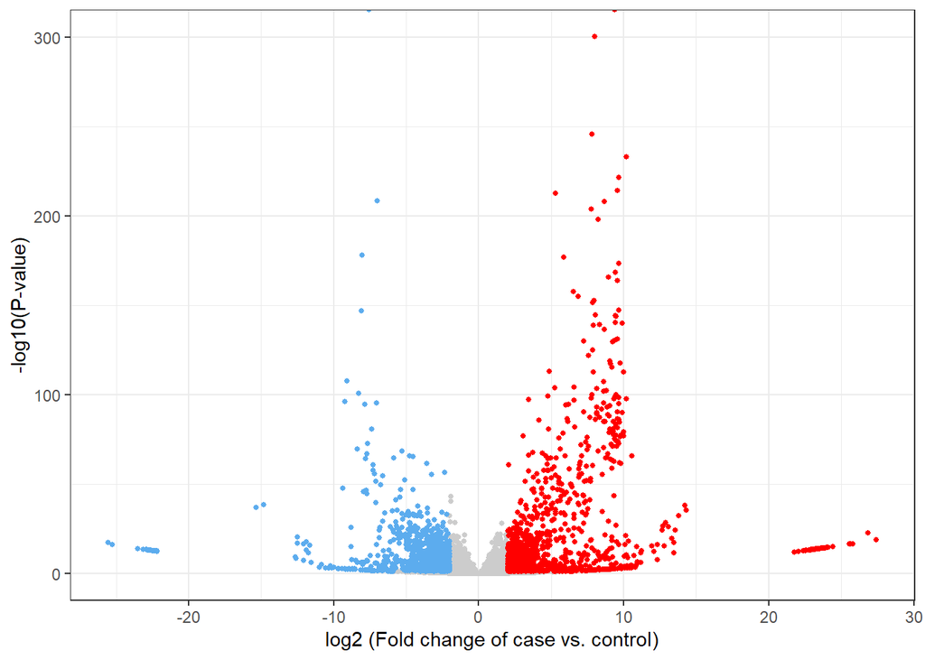

```r
# Create the volcano plot

ggplot()+
  geom_point(data = res_df,
             mapping = aes(x = log2FoldChange, y = -log10(pvalue)),
             col = "grey80", size =1) +
  geom_point(data = subset(res_df, log2FoldChange > 2 & pvalue < 0.05),
             aes(log2FoldChange, -log10(pvalue)), color = "red", size =1)+
  geom_point(data = subset(res_df, log2FoldChange < -2 & pvalue < 0.05),
             aes(log2FoldChange, -log10(pvalue)), color = "steelblue2", size =1)+
  theme_bw()+
  theme(legend.title =element_blank())+
  labs(x = "log2 (Fold change of case vs. control)", y= "-log10(P-value)")
```

2. Use DESeq2::plotDispEsts to make a dispersion plot and find out the meaning of this plot.

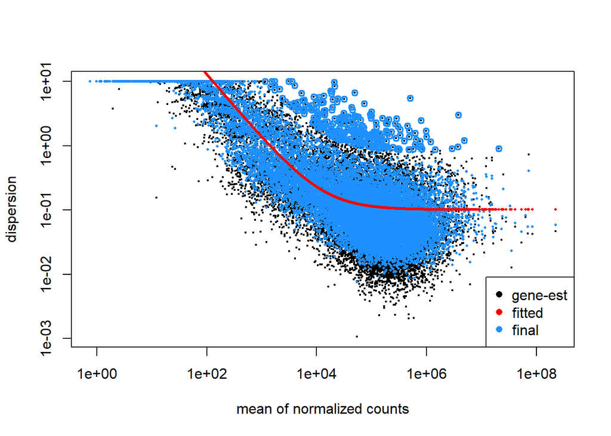

```r
plotDispEsts(dds)
```

3. Explore lfcThreshold argument of the DESeq2::results function. What is its default value? What does it mean to change the default value to, for instance, 1?

```
results(object, contrast, name, lfcThreshold = 0,
  altHypothesis = c("greaterAbs", "lessAbs", "greater", "less"),
  listValues = c(1, -1), cooksCutoff, independentFiltering = TRUE,
  alpha = 0.1, filter, theta, pAdjustMethod = "BH", filterFun,
  format = c("DataFrame", "GRanges", "GRangesList"), test,
  addMLE = FALSE, tidy = FALSE, parallel = FALSE,
  BPPARAM = bpparam(), minmu = 0.5)
```

*As we can see in the function’s arguments, the default value of lfcThreshold is 0.* *The argument specify a threshold of minimum absolute log2 fold change for a gene to be considered differentialy expressed.* *Changing its value to 1, will mean that only genes with log2 fold change of more than 1 or less than -1 between the conditions and with FDR of less than specified alpha will be considered significantly differentialy expressed.*

4. What is independent filtering? What happens if we don’t use it? Google independent filtering statquest and watch the online video about independent filtering.

*Filtering out genes with low read counts that might affect the results by producing type I error - false positives.* *If we don’t use it, we might falsely identify genes as significantly changed between conditions although they are not.*

5. Re-do the differential expression analysis using the edgeR package. Find out how much DESeq2 and edgeR agree on the list of differentially expressed genes.

```r
#Create counts object
dgList <- DGEList(counts=counts, genes=rownames(counts))

#filter the same genes that we filtered for DESeq2.
dgList <- dgList[threshold, ]

#set up the experimental design

design <- model.matrix(~metadata$group)
rownames(design) <- rownames(metadata)

#normalize and estimate dispersion

dgList <- calcNormFactors(dgList)
dgList <- estimateDisp(dgList, design,robust=TRUE,prior.df=1)

#run EdgeR
fit <- glmQLFit(dgList, design)
lrt <- glmQLFTest(fit)
dge<-as.data.frame(topTags(lrt,n=Inf))
dge$dispersion<-lrt$dispersion

# extract significant genes
dge<-merge(dge,lrt$fitted.values,by='row.names')
rownames(dge)=dge$Row.names
dge$Row.names=NULL
dge<-dge[order(dge$PValue),]
dge_sig <- dge %>% mutate(threshold = (FDR < 0.05 & abs(logFC) >= 2)) %>%
        filter(threshold == TRUE)


dge_sig_up <- dge_sig %>% filter(logFC > 0)
dge_sig_down <- dge_sig %>% filter(logFC < 0)



length(rownames(dge_sig_up))
```

```
## [1] 797
```

```r
length(rownames(dge_sig_down))
```

```
## [1] 923
```

```
## [1] "98.08% of the genes in that were identified by edgeR are also in DESeq2 results."
```

```
## [1] "33Genes in that were identified by edgeR are missing from DESeq2 results."
```

```
## [1] "and 308Genes in that were identified by DESeq2 are missing from edgeR results."
```

6. Use the compcodeR package to run the differential expression analysis using at least three different tools and compare and contrast the results following the compcodeR vignette.